### Qualidade de Vinhos

##### por Anderson de Carvalho

09 de Outubro de 2018

Este relatório explora um dataset com mais de 1.500 registros de amostras de vinho avaliadas e classificadas por especialistas em vinho.

```
## [1] 1599   13
```

```
## 'data.frame':    1599 obs. of  13 variables:
##  $ X                   : int  1 2 3 4 5 6 7 8 9 10 ...
##  $ fixed.acidity       : num  7.4 7.8 7.8 11.2 7.4 7.4 7.9 7.3 7.8 7.5 ...
##  $ volatile.acidity    : num  0.7 0.88 0.76 0.28 0.7 0.66 0.6 0.65 0.58 0.5 ...
##  $ citric.acid         : num  0 0 0.04 0.56 0 0 0.06 0 0.02 0.36 ...
##  $ residual.sugar      : num  1.9 2.6 2.3 1.9 1.9 1.8 1.6 1.2 2 6.1 ...
##  $ chlorides           : num  0.076 0.098 0.092 0.075 0.076 0.075 0.069 0.065 0.073 0.071 ...
##  $ free.sulfur.dioxide : num  11 25 15 17 11 13 15 15 9 17 ...
##  $ total.sulfur.dioxide: num  34 67 54 60 34 40 59 21 18 102 ...
##  $ density             : num  0.998 0.997 0.997 0.998 0.998 ...
##  $ pH                  : num  3.51 3.2 3.26 3.16 3.51 3.51 3.3 3.39 3.36 3.35 ...
##  $ sulphates           : num  0.56 0.68 0.65 0.58 0.56 0.56 0.46 0.47 0.57 0.8 ...
##  $ alcohol             : num  9.4 9.8 9.8 9.8 9.4 9.4 9.4 10 9.5 10.5 ...
##  $ quality             : int  5 5 5 6 5 5 5 7 7 5 ...
```

O dataset tem 1.599 observações e 13 atributos.

# Seção de Gráficos Univariados

```
##        X          fixed.acidity   volatile.acidity  citric.acid
##  Min.   :   1.0   Min.   : 4.60   Min.   :0.1200   Min.   :0.000
##  1st Qu.: 400.5   1st Qu.: 7.10   1st Qu.:0.3900   1st Qu.:0.090
##  Median : 800.0   Median : 7.90   Median :0.5200   Median :0.260
##  Mean   : 800.0   Mean   : 8.32   Mean   :0.5278   Mean   :0.271
##  3rd Qu.:1199.5   3rd Qu.: 9.20   3rd Qu.:0.6400   3rd Qu.:0.420
##  Max.   :1599.0   Max.   :15.90   Max.   :1.5800   Max.   :1.000
##  residual.sugar     chlorides       free.sulfur.dioxide
##  Min.   : 0.900   Min.   :0.01200   Min.   : 1.00
##  1st Qu.: 1.900   1st Qu.:0.07000   1st Qu.: 7.00
##  Median : 2.200   Median :0.07900   Median :14.00
##  Mean   : 2.539   Mean   :0.08747   Mean   :15.87
##  3rd Qu.: 2.600   3rd Qu.:0.09000   3rd Qu.:21.00
##  Max.   :15.500   Max.   :0.61100   Max.   :72.00
##  total.sulfur.dioxide    density             pH          sulphates
##  Min.   :  6.00       Min.   :0.9901   Min.   :2.740   Min.   :0.3300
##  1st Qu.: 22.00       1st Qu.:0.9956   1st Qu.:3.210   1st Qu.:0.5500
##  Median : 38.00       Median :0.9968   Median :3.310   Median :0.6200
##  Mean   : 46.47       Mean   :0.9967   Mean   :3.311   Mean   :0.6581
##  3rd Qu.: 62.00       3rd Qu.:0.9978   3rd Qu.:3.400   3rd Qu.:0.7300
##  Max.   :289.00       Max.   :1.0037   Max.   :4.010   Max.   :2.0000
##     alcohol         quality
##  Min.   : 8.40   Min.   :3.000
##  1st Qu.: 9.50   1st Qu.:5.000
##  Median :10.20   Median :6.000
##  Mean   :10.42   Mean   :5.636
##  3rd Qu.:11.10   3rd Qu.:6.000
##  Max.   :14.90   Max.   :8.000
```

A variável ‘X’ parece ser um índice sequencial.

Seguiu-se em observação das distribuções das demais variáveis.

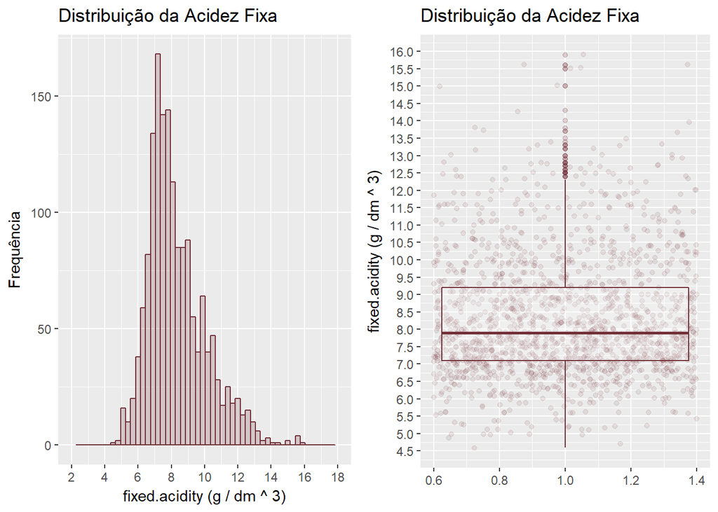

```
##    Min. 1st Qu.  Median    Mean 3rd Qu.    Max.
##    4.60    7.10    7.90    8.32    9.20   15.90
```

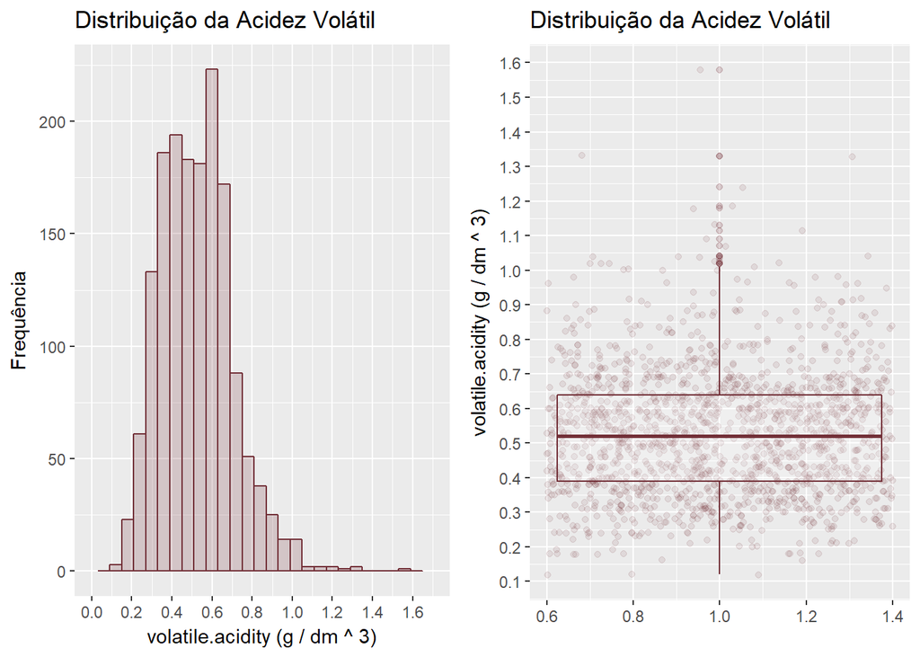

```
##    Min. 1st Qu.  Median    Mean 3rd Qu.    Max.
##  0.1200  0.3900  0.5200  0.5278  0.6400  1.5800
```

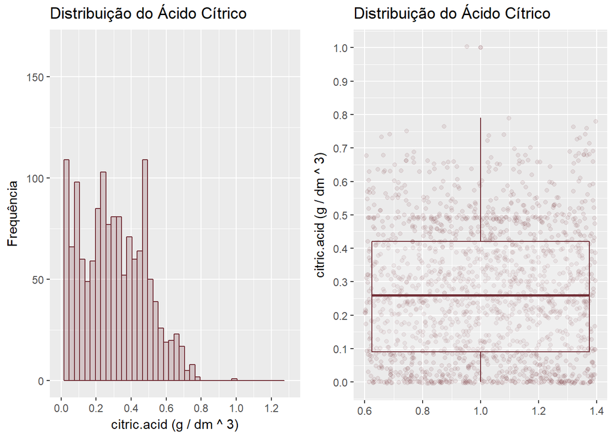

[output not shown]

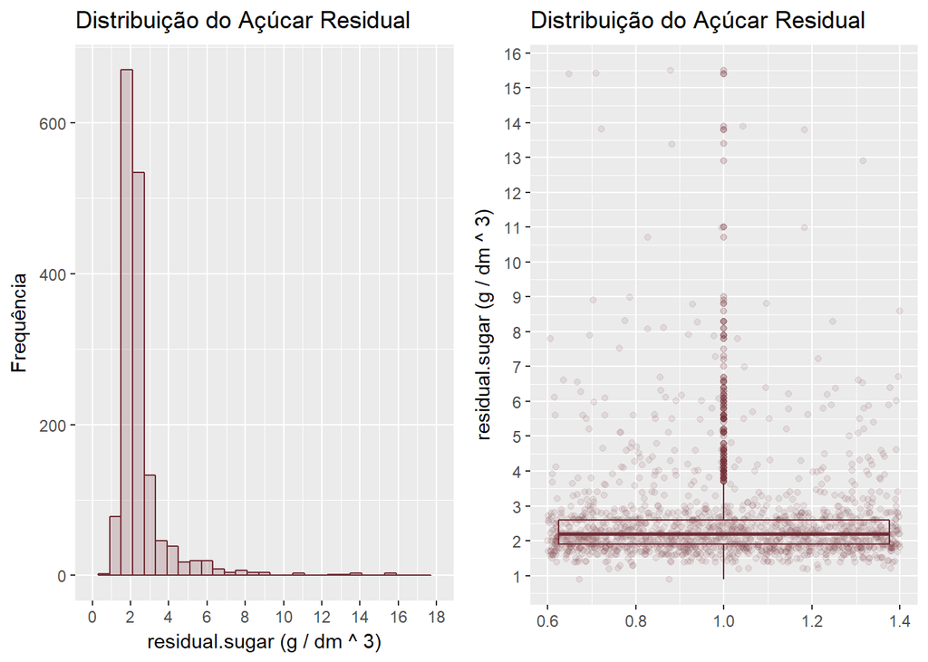

[output not shown]

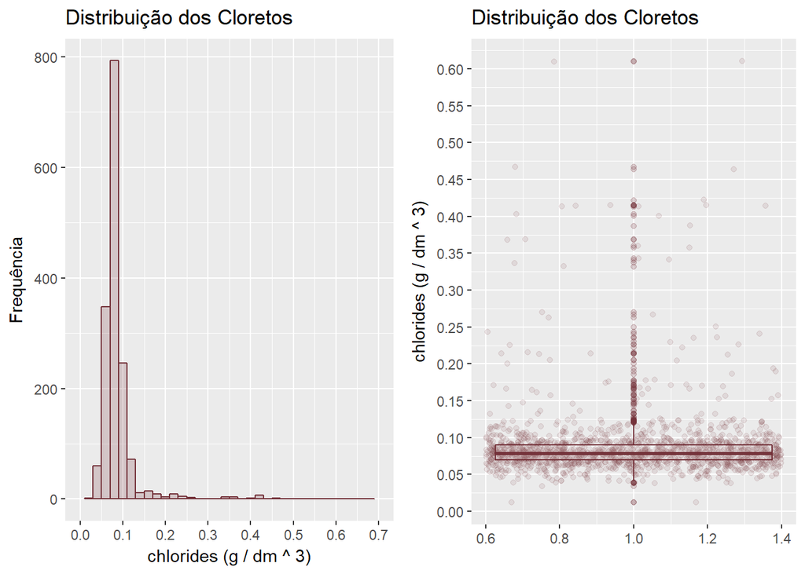

[output not shown]

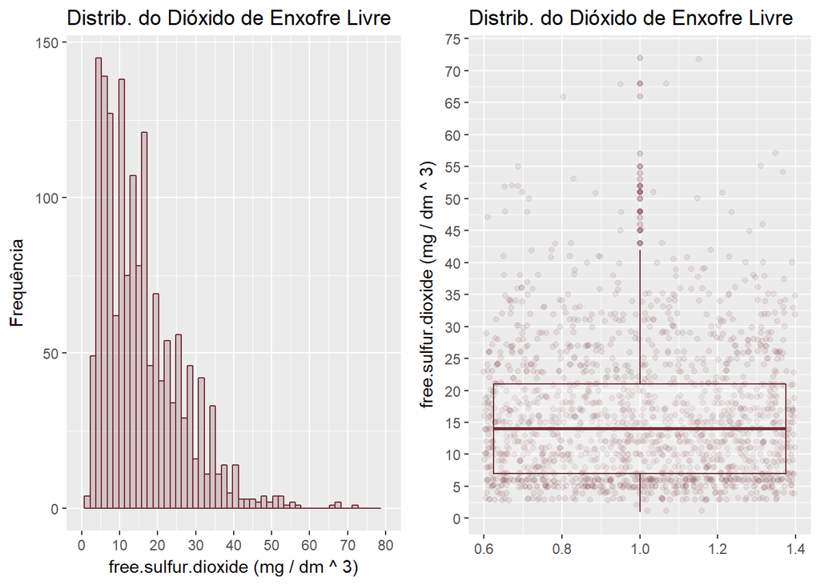

[output not shown]

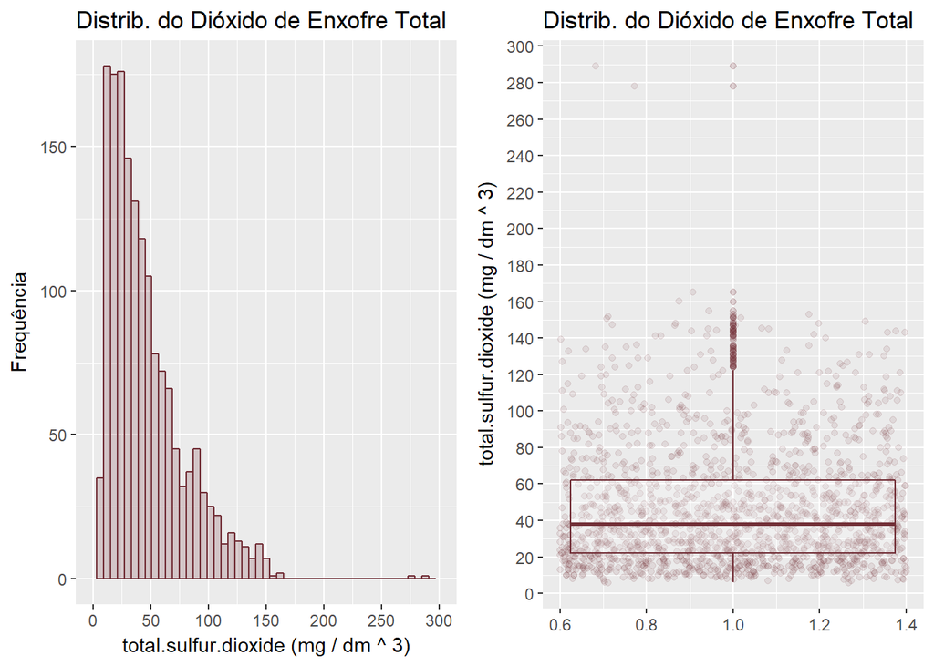

[output not shown]

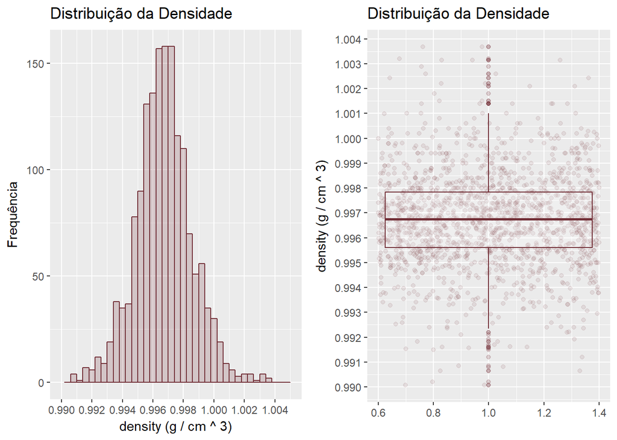

[output not shown]

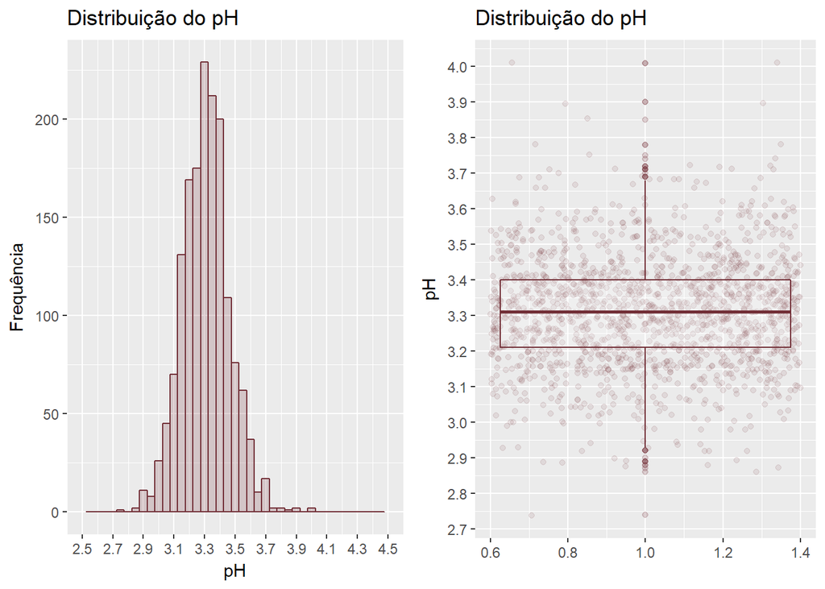

[output not shown]

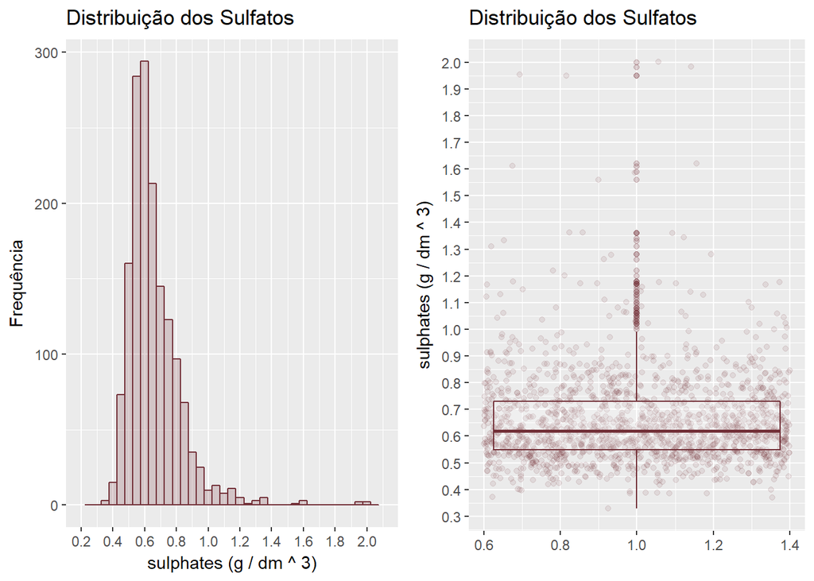

[output not shown]

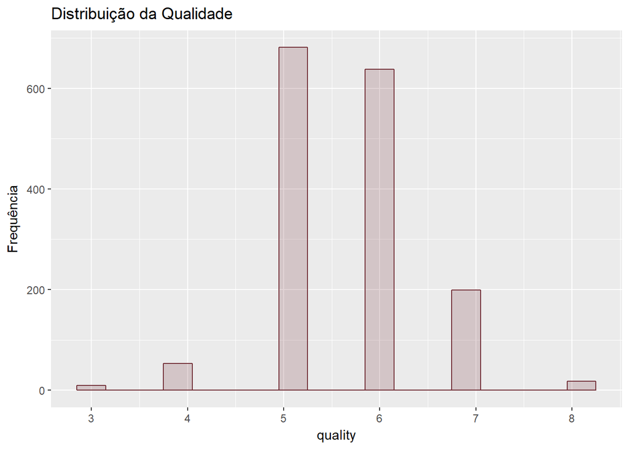

[output not shown]

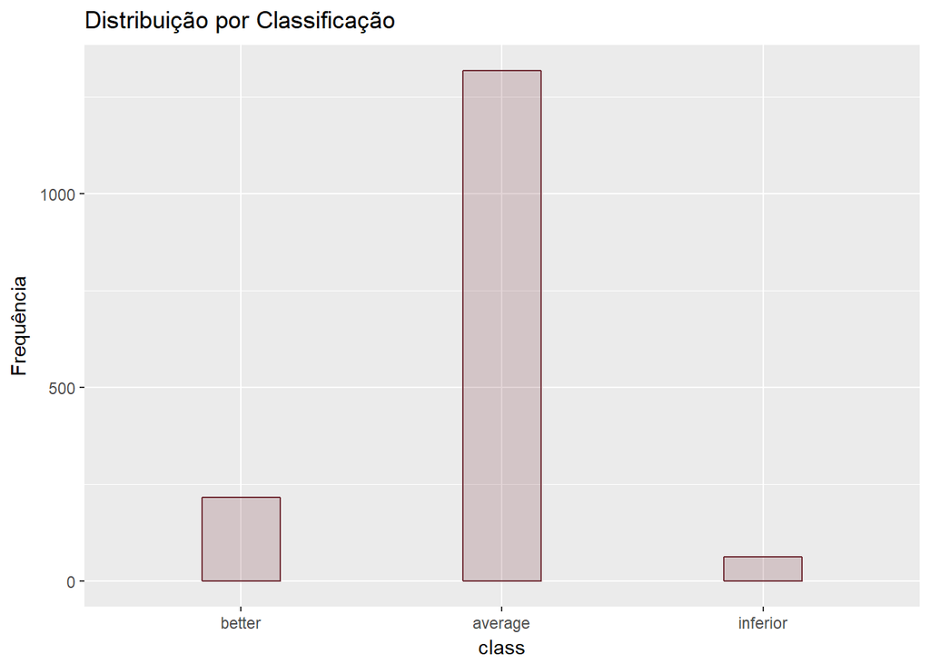

```
##   wd$class    n    percent
## 1  average 1319 0.82489056
## 2   better  217 0.13570982
## 3 inferior   63 0.03939962
```

Foram percebidos outliers em ‘fixed.acidity’, ‘volatile.acidity’, ‘citric.acid’, ‘residual.sugar’, ‘chlorides’, ‘sulfur.dioxide’, ‘total.sulfur.dioxide’ e ‘sulphates’.

A distribuição de observações em relação a qualidade dos vinhos parece desequilibrada, com mais observações de vinhos medianos.

# Análise Univariada

### Qual é a estrutura do conjunto de dados?

O dataset tem 1.599 observações, 11 atributos + 1 atributo de saída.

Atributos de entrada (baseados em testes físico-químicos):

01 - fixed.acidity / acidez fixa (ácido tartárico - g / dm ^ 3)  
02 - volatile.acidity / acidez volátil (ácido acético - g / dm ^ 3)  
03 - citric.acid / ácido cítrico (g / dm ^ 3)  
04 - residual.sugar / açúcar residual (g / dm ^ 3)  
05 - chlorides / cloretos (cloreto de sódio - g / dm ^ 3  
06 - free.sulfur.dioxide / dióxido de enxofre livre (mg / dm ^ 3)  
07 - total.sulfur.dioxide / dióxido de enxofre total (mg / dm ^ 3)  
08 - density / densidade (g / cm ^ 3)  
09 - pH  
10 - sulphates / sulfatos (sulfato de potássio - g / dm3)  
11 - alcohol / álcool (% em volume)

Atributo de saída (baseado em dados sensoriais):

12 - quality / qualidade (pontuação entre 0 e 10)

### Quais são os principais atributos de interesse deste conjunto de dados?

O principal atributo é ‘quality’.

### Quais outros atributos você acha que podem lhe auxiliar na investigação destes atributos de interesse?

Estima-se compreender quais características influenciaram na apreciação dos vinhos pelos especialista. Intuitivamente, optou-se inicialmente pelos os atributos que parecem ter relação com a acidez, doçura e teor alcólico dos vinhos: ‘fixed.acidity’, ‘volatile.acidity’, ‘citric.acid’, ‘residual.sugar’ e ‘alcohol’.

### Você criou novas variáveis a partir dos atributos existentes no conjunto de dados?

Sim. Foi criada a váriavel ‘class’ que distribui a qualidade dos vinhos em 3 classes: ‘better’, ‘average’ e ‘inferior’.

### Dos atributos investigados, distribuições incomuns foram encontradas? Você aplicou operações nos dados para limpá-los, ajustá-los ou mudar a forma dos dados? Se sim, por quê?

Sim, percebeu-se a existência de outliers nos atributos: ‘fixed.acidity’, ‘volatile.acidity’, ‘citric.acid’, ‘residual.sugar’, ‘chlorides’, ‘free.sulfur.dioxide’, ‘total.sulfur.dioxide’ e ‘sulphates’.

Na documentação que acompanha o dataset é mensionada a existência de muitas observações de vinhos medianos e poucas de ruins e excelentes. E que uma detecção de outliers poderia, talvez, identificar os poucos piores e excelentes vinhos. Remover os outliers poderia prejudicar a compreensão de quais características tornam um vinho excelente ou ruim.

Portanto, optou-se por não remover os outliers.

# Seção de Gráficos Bivariados

Uma matriz de correlação é de grande ajuda para uma exploração incial da correlações.

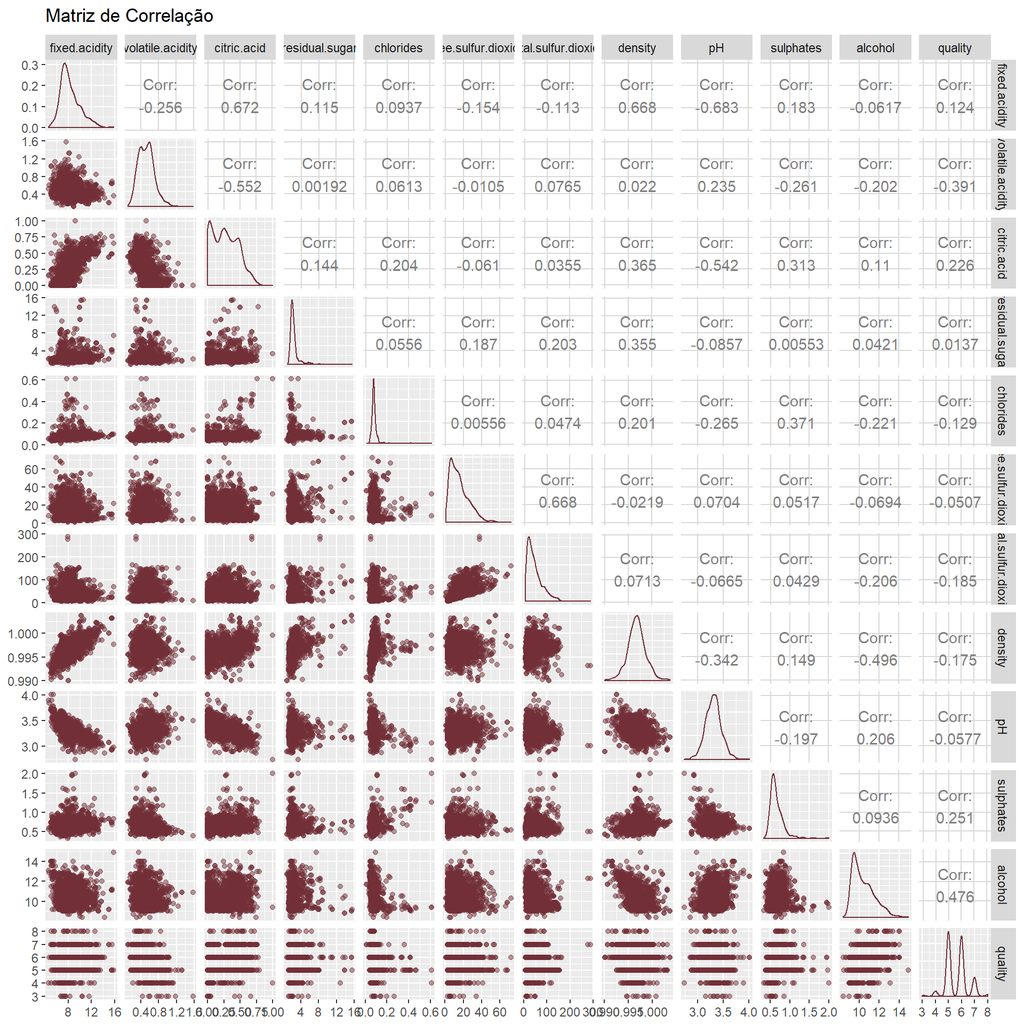

Reconhecidas as correlações prosseguiu-se na observação das mais significativas.

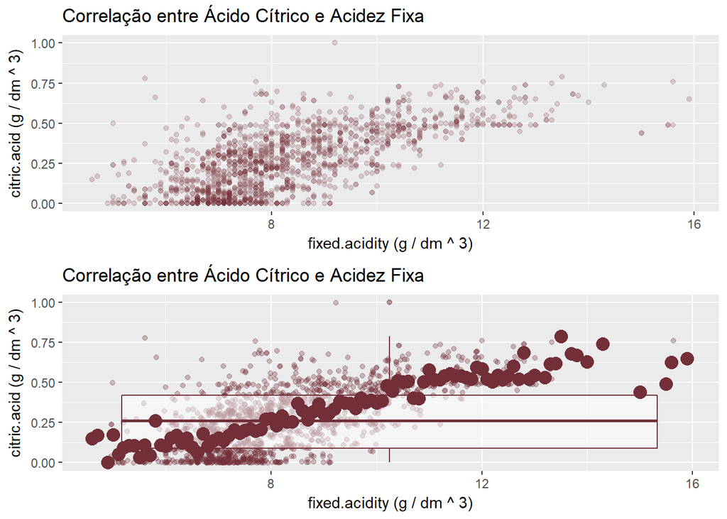

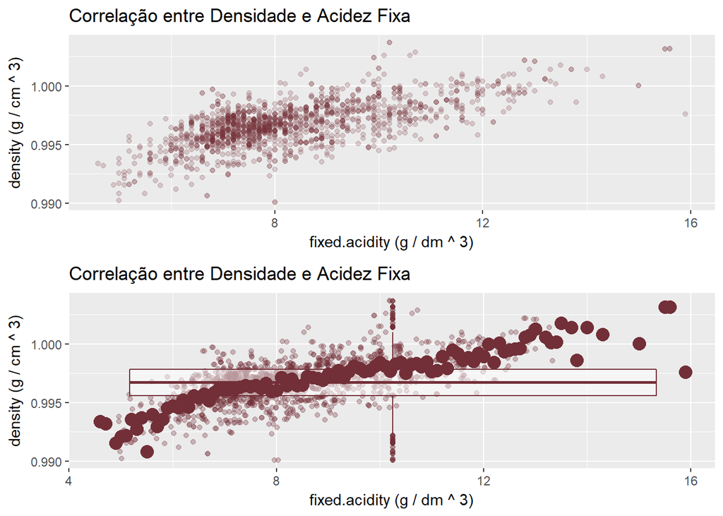

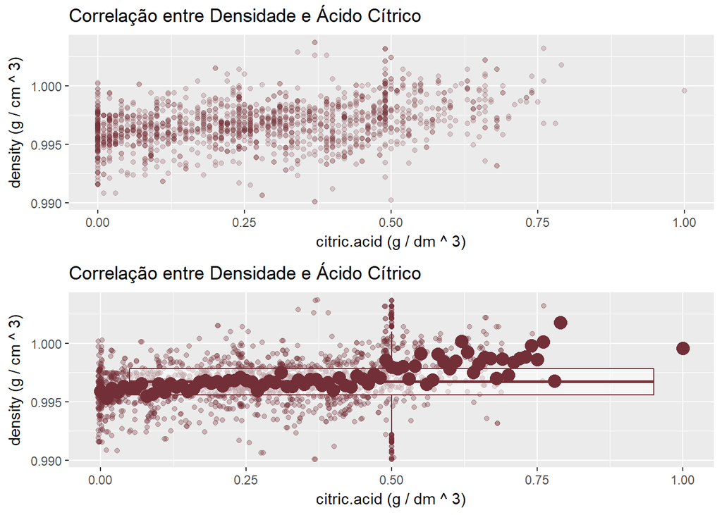

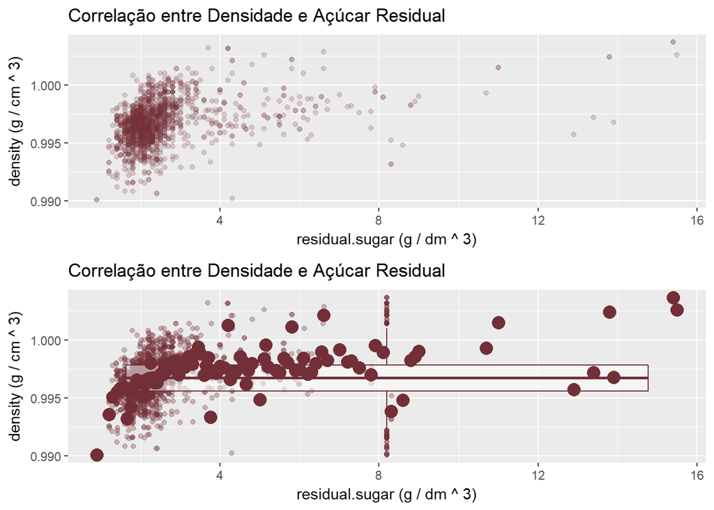

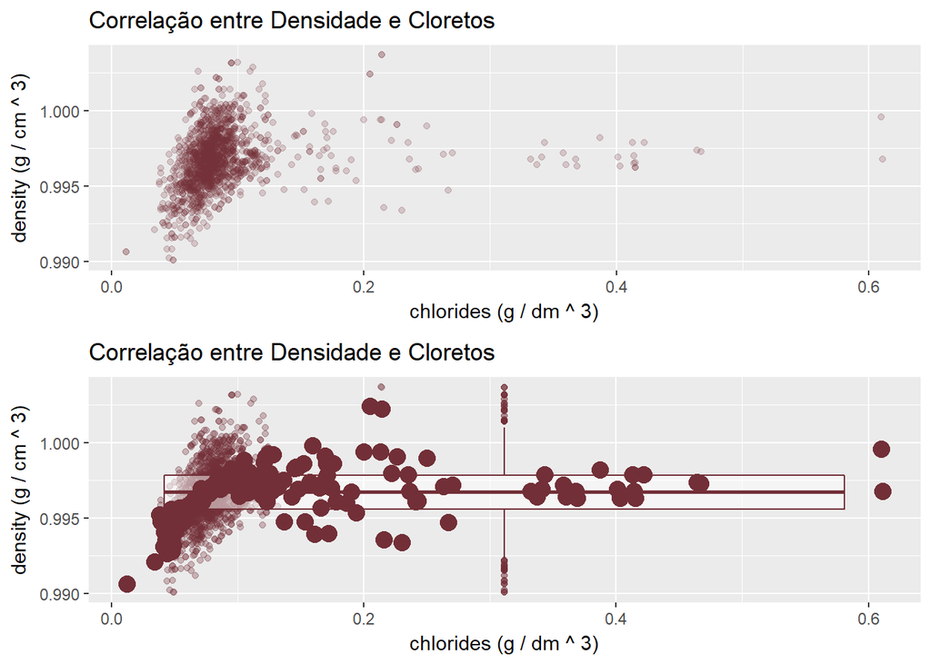

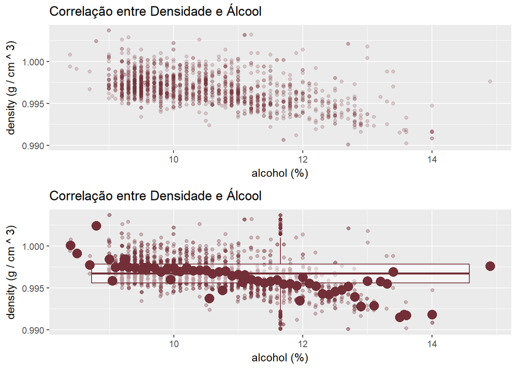

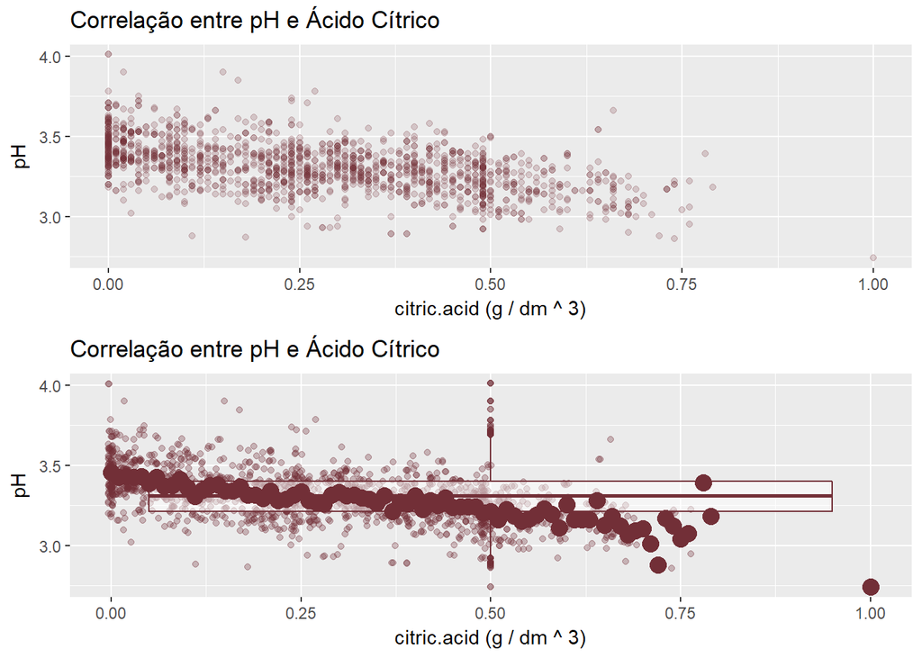

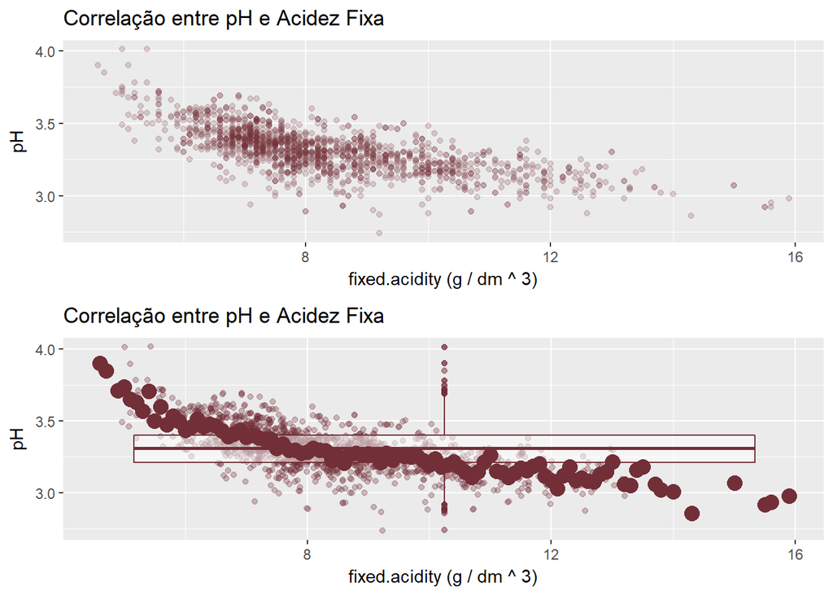

Observou-se uma forte correlação negativa entre ‘fixed.acidty’ e ‘pH’. Entre ‘citric.acid’ e ‘pH’ também há, porém mais fraca.  
Pareceu curioso que ‘volatile.acidity’ tenha correlação positiva com ‘pH’.

O atributo density tem correlação moderada com ‘citric.acid’, ‘residual.sugar’ e ‘chlorides’.

Após observar as correlações entre algumas variáveis, seguiu-se na observação das correlações com a variável de interesse.

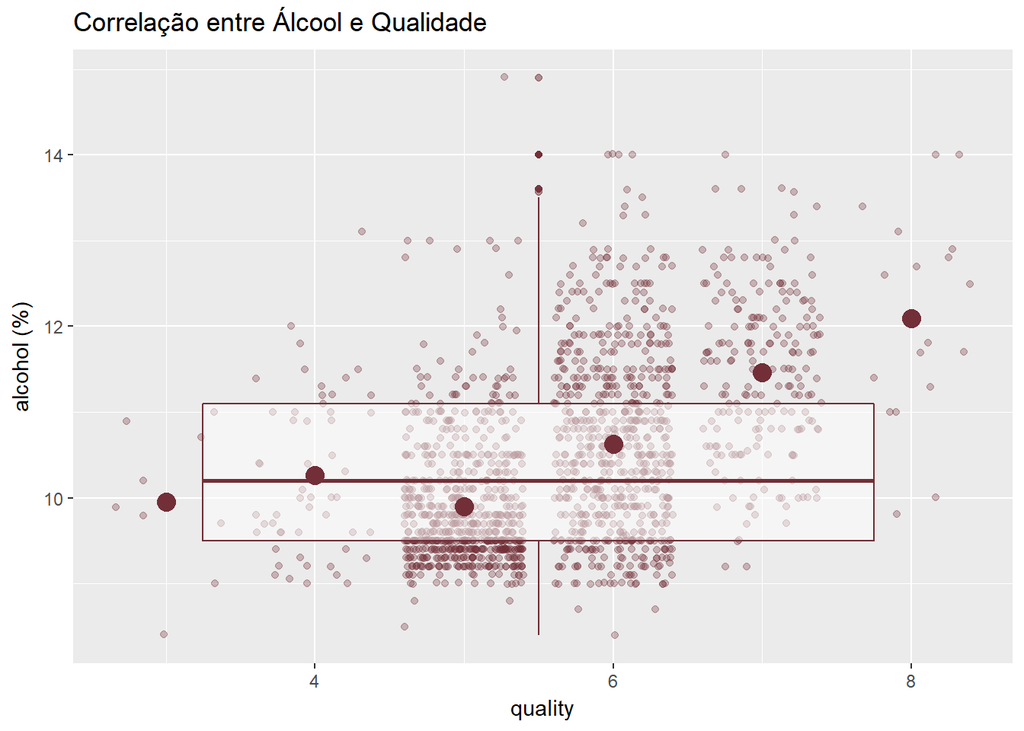

Ao que parece, vinhos considerados de melhor qualidade (acima de 7), tem maior concentração de álcool.

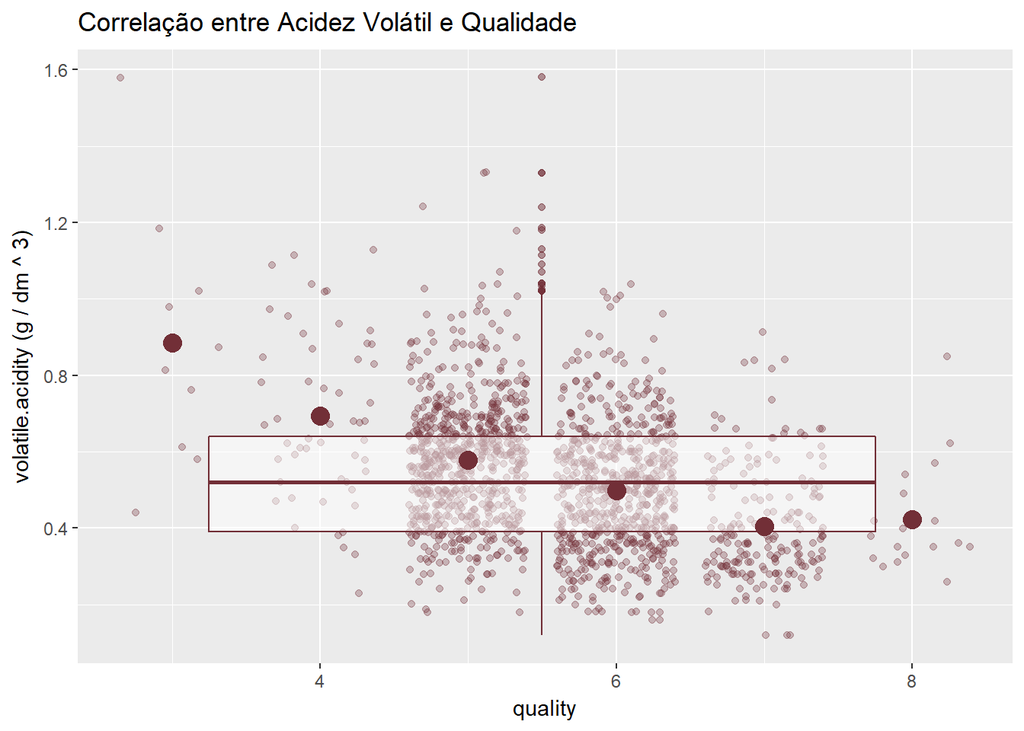

Parece bastante claro que a qualidade varia inversamente em relação a acidez volátil. Maior acidez volátil foi considerado pior.

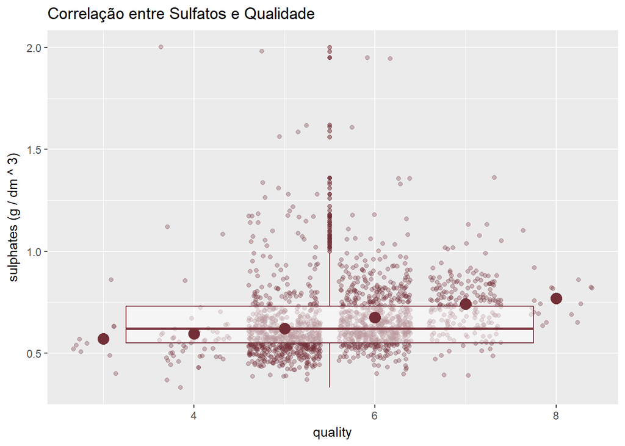

Curioso, mas sulfatos parecem ter sua importância para os vinhos considerados melhores.

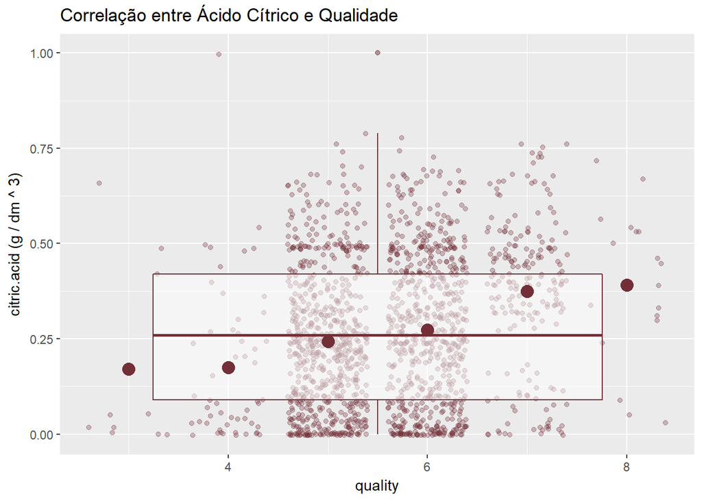

O ácido cítrico parece ter influência positiva na qualidade observada nos vinhos.

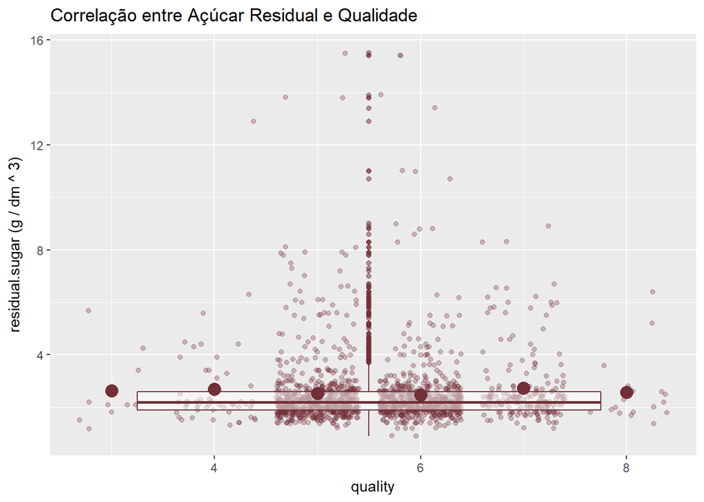

O açúcar residual parece ter pouca expressão na qualidade observada.

As correlações de ‘quality’ com ‘alchohol’, ‘volatility.acidity’ e ‘citric.acid’ confirmaram algumas intuições.  
Mas outras surpreenderam, como ‘sulphates’ e ‘residual.sugar’.

# Análise Bivariada

### Discuta sobre alguns dos relacionamentos observados nesta parte da investigação. Como os atributos de interesse variaram no conjunto de dados?

Com baixa correlação indica que a qualidade não parece ser afetada, ou ser muito pouco afetada, por ‘fixed.acidity’.

Quando a concentração de ‘volatile.acidity’ diminui, a qualidade parece aumentar. Os vinhos inferiores e médios, são os que tem mais altos índices.

Nos vinhos melhores a concentração de ‘citric.acid’ e ‘sulphates’ é maior.

O ‘residual.sugar’ parece não aparesentar a influência esperada na boa qualidade.

Aparentemente o ‘alchohol’ é o atributo de maior influência na qualidade dos vinhos.

### Você observou algum relacionamento interessante entre os outros atributos (os que não são de interesse)?

Sim, inesperadamente ‘sulphates’ parece ter maior influência nos melhores vinhos do que ‘residual.sugar’.

Algo curioso também é que ‘volatile.acidity’ tem correlação positiva com ‘pH’, enquanto ‘citric.acid’ e ‘fixed.acidity’ tem correlação negativa. Sendo o pH um índice referente a acidez e basicidade de soluções, é intrigante que componentes relativos a acidez tenham correlações inversas em relação a ele. Talvez um químico possa explicar.

### Qual foi o relacionamento mais forte encontrado?

As correlações mais fortes com ‘quality’ foram de 0.476, com ‘alchohol’ e negativa de -0.391, com ‘volatile.acidity’.

# Seção de Gráficos Multivariados

Em seguida prosseguiu-se tentando compreender melhor, como as variáveis que parecem ter mais influência na qualidade afetam a mesma, nas diferentes classes definidas.

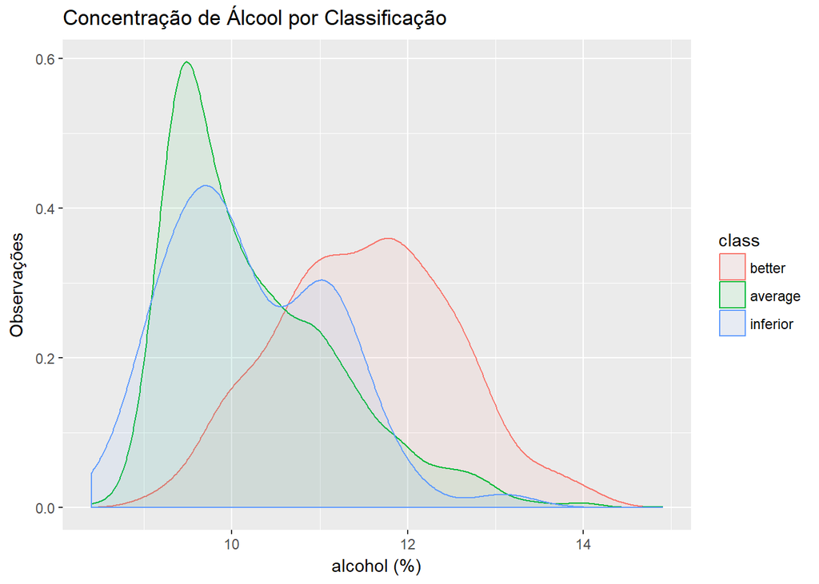

Nos melhores vinhos a concentração de álcool é próxima a 12, enquanto em grande parte os medianos e inferiores é abaixo de 10.

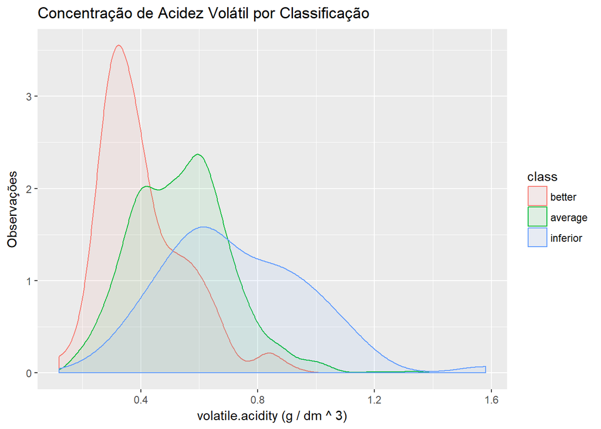

A concentração de acidez volátil aparece abaixo de 0.4 para os melhores vinhos e próxima a 0.6 para os demais.

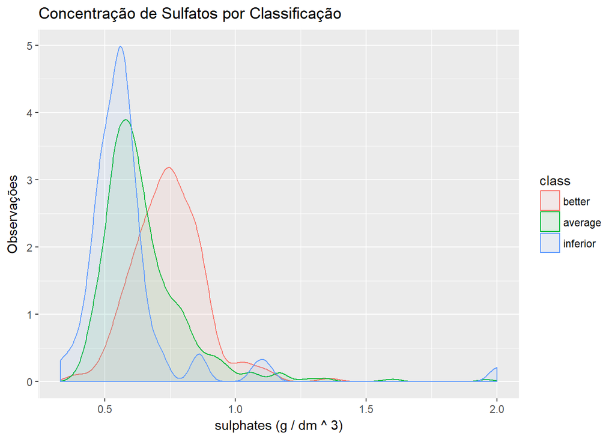

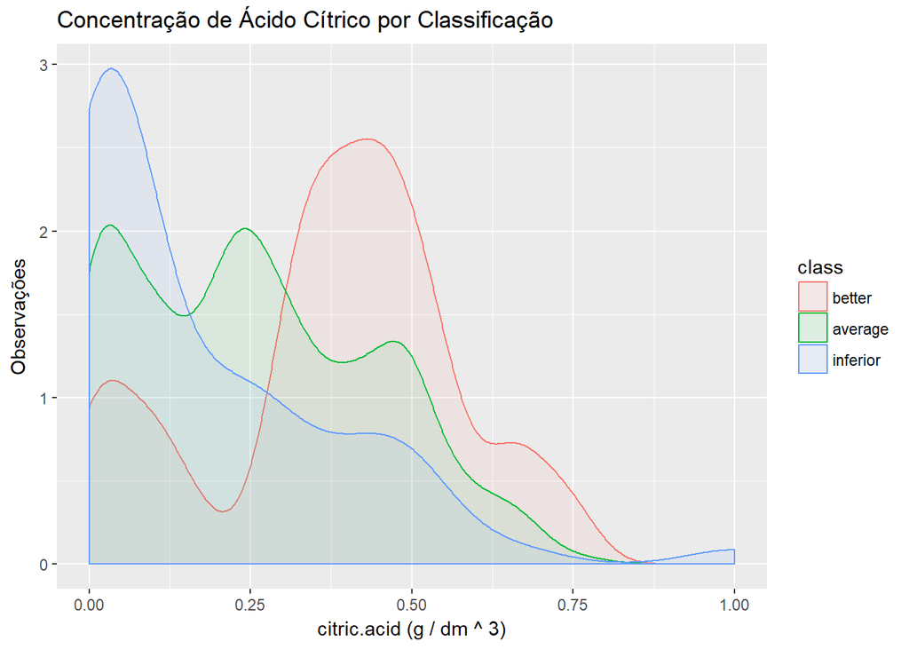

A grande parte dos vinhos inferiores tem concentração de ácido cítrico abaixo de 0.25.  
Parte dos vinhos medianos tem concentrações entre 0 e 0.50, enquanto a maioria dos melhores, próximo a 0.40.

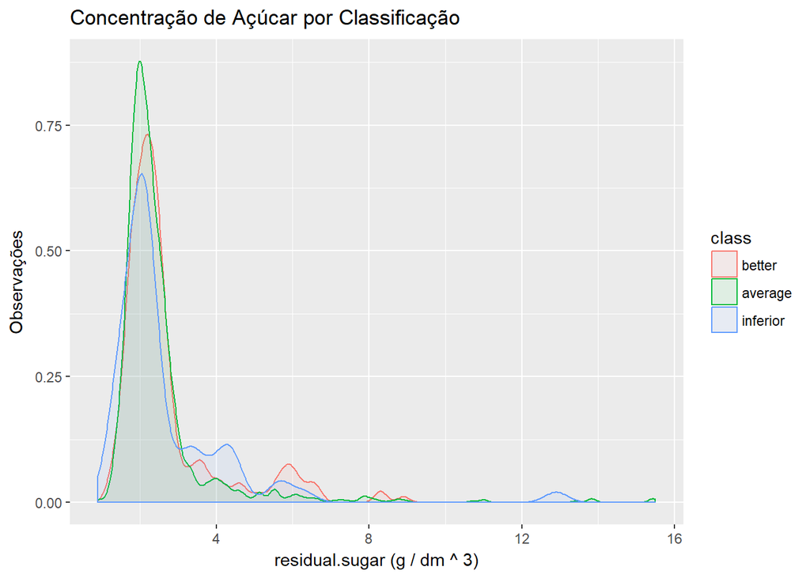

A concentração residual de açúcar apresenta-se próxima a 2 para a maioria dos vinhos.

## Modelo Linear

Optou-se por experimentar um modelo linear usando as principais variáveis.

```
##
## Calls:
## model1: lm(formula = as.numeric(quality) ~ alcohol, data = training_data)
## model2: lm(formula = as.numeric(quality) ~ alcohol + sulphates, data = training_data)
## model3: lm(formula = as.numeric(quality) ~ alcohol + sulphates + volatile.acidity,
##     data = training_data)
## model4: lm(formula = as.numeric(quality) ~ alcohol + sulphates + volatile.acidity +
##     citric.acid, data = training_data)
## model5: lm(formula = as.numeric(quality) ~ alcohol + sulphates + volatile.acidity +
##     citric.acid + fixed.acidity, data = training_data)
## model6: lm(formula = as.numeric(quality) ~ alcohol + sulphates + volatile.acidity +
##     citric.acid + fixed.acidity + pH, data = training_data)
##
## ======================================================================================
##                      model1     model2     model3     model4     model5     model6
## --------------------------------------------------------------------------------------
##   (Intercept)       2.060***   1.574***   2.995***   3.021***   2.340***   3.253***
##                    (0.230)    (0.234)    (0.255)    (0.263)    (0.293)    (0.735)
##   alcohol           0.341***   0.327***   0.282***   0.282***   0.298***   0.305***
##                    (0.022)    (0.022)    (0.021)    (0.021)    (0.021)    (0.021)
##   sulphates                    0.955***   0.607***   0.621***   0.637***   0.621***
##                               (0.134)    (0.130)    (0.134)    (0.132)    (0.133)
##   volatile.acidity                       -1.353***  -1.386***  -1.499***  -1.491***
##                                          (0.122)    (0.143)    (0.143)    (0.143)
##   citric.acid                                       -0.058     -0.629***  -0.660***
##                                                     (0.136)    (0.176)    (0.178)
##   fixed.acidity                                                 0.086***   0.073***
##                                                                (0.017)    (0.020)
##   pH                                                                      -0.260
##                                                                           (0.192)
## --------------------------------------------------------------------------------------
##   R-squared             0.2        0.2        0.3        0.3        0.3        0.3
##   adj. R-squared        0.2        0.2        0.3        0.3        0.3        0.3
##   sigma                 0.7        0.7        0.7        0.7        0.6        0.6
##   F                   239.8      151.7      154.9      116.1      100.2       83.9
##   p                     0.0        0.0        0.0        0.0        0.0        0.0
##   Log-likelihood    -1039.4    -1014.5     -956.6     -956.5     -944.2     -943.2
##   Deviance            490.7      465.8      412.8      412.7      402.2      401.5
##   AIC                2084.9     2037.0     1923.2     1925.0     1902.3     1902.5
##   BIC                2099.5     2056.5     1947.5     1954.2     1936.4     1941.4
##   N                   959        959        959        959        959        959
## ======================================================================================
```

O melhor valor R^2 obtido foi 0.3. Talvez a alta quantidade de observações relativas a vinhos medianos possa ter prejudicado a predição.

# Análise Multivariada

### Discuta sobre os relacionamentos observados nesta parte da investigação. Quais atributos que fortaleceram os demais na observação das variáveis de interesse?

Nos gráficos é perceptível que densidade de ‘alchohol’ aumenta nos melhores vinhos, enquanto diminui nos medianos e inferiores. O mesmo acontece em menor escala com ‘sulphates’ e ‘citric.acid’. E inversamente com ‘volatile.acidity’.

Embora os vinhos melhores aparentem ter menos ‘volatile.acidity’, em uma correlação negativa de -0.391, a diferença que os destingue dos demais parece pequena.

Aparentemente a maior parte do vinhos tem um índice parecido de ‘residual.sugar’.

Muito mais pela análise dos gráficos, do que pelas predições do modelo, considerou-se que a maior influência sobre a opinião dos profissionais que avaliaram os vinhos parece ter vindo dos seguintes atributos: ‘alchohol’, ‘volatile.acidity’, ‘sulphates’ e ‘citric.acid’.

### Interações surpreendentes e/ou interessantes foram encontradas entre os atributos?

Sim, foi inesperado perceber que ‘sulphates’ aparentemente tem mais importância na qualidade de um bom vinho, do que ‘citric.acid’ e ‘residual.sugar’.

### OPCIONAL: Modelos foram criados usando este conjunto de dados? Discuta sobre os pontos fortes e as limitações do seu modelo.

Sim, experimentou-se um modelo linear com algumas variáveis.

Obteve-se uma baixa pontuação de R^2, muito provavelmente pela reduzida quantidade de observações de vinhos inferiores e melhores, em relação aos medianos.